# Fieldworker deployment Mozambique

Calculate the fieldworkers required for questionnaires in all households in Mozambique. This is done by

- finding a route that passes all households in a cluster exactly once,
- assuming an average travel speed, and
- estimating visit duration from size of household (using [a linear model](https://github.com/databrew/bohemia/tree/master/scripts/fullcensus/report)).

Clusters are then classified by criticality, i.e. which clusters require more work than a field worker (work unit) can do between visits.

NOTE: this Rmd does not rely on igraph functionality

# Setup

|  | hamlet_code | cluster | core_or_buffer | hh_id | lng | lat | n_people | n_children | n_females | hh_main_wall_material | hh_main_energy_source_for_lighting | hh_main_building_type | cook_main_water_source | cook_time_to_water |
| --- | --- | --- | --- | --- | --- | --- | --- | --- | --- | --- | --- | --- | --- | --- |
| 1 | COC | 1 | buffer | COC-012 | 35.61246 | -18.00435 | 3 | 0 | 2 | other PAUS MATICADOS E CAPIM | firewood | traditional_mud_house | water_from_river | between_30_60_min |
| 2 | COC | 1 | buffer | COC-011 | 35.61284 | -18.00438 | 6 | 1 | 3 | bamboo other CAPIM | firewood | hut | water_from_river | between_10_30_min |
| 3 | COC | 1 | buffer | COC-039 | 35.61295 | -18.00480 | 5 | 3 | 2 | adobe_block bamboo other CAPIM | batteries | traditional_mud_house | water_from_river | between_10_30_min |
| 4 | COC | 1 | buffer | COC-022 | 35.60926 | -18.00459 | 6 | 0 | 4 | bark other bamboo CAPIM | firewood | hut | water_from_river | between_30_60_min |
| 5 | COC | 1 | buffer | COC-010 | 35.61298 | -18.00429 | 7 | 3 | 3 | other bark PAUS E CAPIM | batteries | hut | water_from_river | between_30_60_min |
| 6 | COC | 1 | buffer | COC-013 | 35.61240 | -18.00487 | 9 | 3 | 5 | adobe_block | batteries | hut | lagoon | between_10_30_min |

Quick look at the data

```r
summary( df.raw.households )
```

```
 hamlet_code           cluster       core_or_buffer
 Length:12504       Min.   :  1.00   Length:12504
 Class :character   1st Qu.: 36.00   Class :character
 Mode  :character   Median : 79.00   Mode  :character
                    Mean   : 81.69
                    3rd Qu.:125.00
                    Max.   :159.00
    hh_id                lng             lat            n_people
 Length:12504       Min.   :35.32   Min.   :-18.23   Min.   : 1.000
 Class :character   1st Qu.:35.68   1st Qu.:-17.97   1st Qu.: 3.000
 Mode  :character   Median :35.74   Median :-17.80   Median : 5.000
                    Mean   :35.90   Mean   :-17.82   Mean   : 5.182
                    3rd Qu.:36.28   3rd Qu.:-17.71   3rd Qu.: 7.000
                    Max.   :36.59   Max.   :-17.51   Max.   :30.000
   n_children       n_females      hh_main_wall_material
 Min.   :0.0000   Min.   : 0.000   Length:12504
 1st Qu.:0.0000   1st Qu.: 1.000   Class :character
 Median :1.0000   Median : 2.000   Mode  :character
 Mean   :0.8911   Mean   : 2.628
 3rd Qu.:1.0000   3rd Qu.: 3.000
 Max.   :9.0000   Max.   :15.000
 hh_main_energy_source_for_lighting hh_main_building_type
 Length:12504                       Length:12504
 Class :character                   Class :character
 Mode  :character                   Mode  :character



 cook_main_water_source cook_time_to_water
 Length:12504           Length:12504
 Class :character       Class :character
 Mode  :character       Mode  :character
```

## Visualize

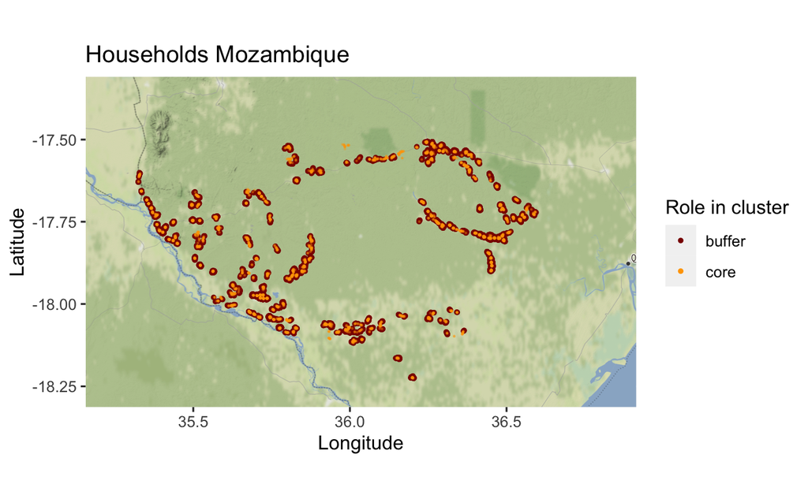

```r
moz <- c(left = 35.29, bottom = -18.2, right = 36.57, top = -17.52)

map.moz <- get_map(location=moz, source="stamen", maptype="watercolor", crop=FALSE)
ggmap( map.moz ) +
  geom_point( data=df.raw.households %>% filter(core_or_buffer=="buffer"), aes(lng, lat, color=core_or_buffer), size=0.8 ) +
  geom_point( data=df.raw.households %>% filter(core_or_buffer=="core"), aes(lng, lat, color=core_or_buffer), size=0.1, alpha=0.3 ) +
  scale_color_manual( values=c("core"="orange", "buffer"="darkred")) +
  labs( title="Households Mozambique",
        x="Longitude",
        y="Latitude",
        color="Role in cluster")
```

# Estimate time effort per cluster

## Work load per household

We assume 20 mins base time for each visit and an additional 15" for each member of the household according to Joe’s linear model. Values are in [h].

```r
df.workload <- df.raw.households %>%
                        mutate( visit_duration = 20/60 + n_people*15/60 ) %>% # 20" base, 15" per person ...
                        select( hh_id, visit_duration, lng, lat, cluster )

df.workload %<>%
  group_by( cluster ) %>%
  summarise( cluster_visit_time = sum(visit_duration),
             lng = mean(lng),
             lat = mean(lat),
             n = n()) %>%
  ungroup()
```

## Tour all households by cluster

Here we look for a route visiting all households in a cluster exactly once. Given an average speed we can take a guess at how long this may take.

The following helper function creates a symmetric adjacency matrix that can be processed by the TSP solver. The solver returns a route in [m].

```r
get_tsp_distance <- function( cluster_no, verbose=0 ) {
  if( verbose==1 )
    sprintf( "Cluster #%d", cluster_no )
  df <- df.raw.households %>%
    filter( cluster == cluster_no )

  nodes <- unique(df$hh_id)
  order <- length(nodes)
  edges <- data.frame( matrix(0L, nrow=order, ncol=order))
  colnames(edges) <- nodes
  rownames(edges) <- nodes
  edges$start <- nodes

  trips <- edges %>%
    pivot_longer(!start, names_to = "dest", values_to = "dist")

  # add geospatial data for both nodes
  trips <- merge( trips, df.raw.households %>% select(hh_id, lat, lng), by.x="start", by.y="hh_id", all.x=T)
  trips <- merge( trips,  df.raw.households %>% select(hh_id, lat, lng), by.x="dest", by.y="hh_id", all.x=T)

  # calculate distances
  trips$dist <- distHaversine(trips[,4:5], trips[,6:7])

  edges <-
    trips %>%
    select( start, dest, dist ) %>%
    pivot_wider( names_from = dest, values_from = dist) %>%
    arrange(start) %>%
    select(sort(current_vars())) %>% # sort by col names
    select(-start)

  colnames(edges) <-c() # if we don't do this we get a 'not symmetric matrix' error ...

  distances <- data.matrix(edges)

  tsp <- TSP(distances)
  tour <- solve_TSP(tsp)

  return(attr(tour, "tour_length"))
}
```

For cluster #1:

```r
print( get_tsp_distance(cluster_no = 1) )
```

```
`current_vars()` is deprecated as of dplyr 0.8.4.
Please use `tidyselect::peek_vars()` instead.
```

```
[1] 6384.117
```

Do this for every cluster. Assume an average speed of 3 km/h and 30" to pack up and leave. This could be adapted to cluster location if desired.

```r
travel_speed <- 3 # kph
df.workload %<>%
  group_by(cluster) %>%
  mutate( tour = get_tsp_distance(cluster)) %>%
  mutate( cluster_travel_time = n*0.5 + (tour/1000)/travel_speed)

df.workload
```

| cluster | cluster_visit_time | lng | lat | n | tour | cluster_travel_time |
| --- | --- | --- | --- | --- | --- | --- |
| 1 | 83.00000 | 35.62109 | -18.00429 | 48 | 6420.990 | 26.140330 |
| 2 | 69.00000 | 35.81672 | -17.56201 | 48 | 10089.139 | 27.363046 |
| 3 | 70.33333 | 35.32740 | -17.61246 | 43 | 5827.076 | 23.442359 |
| 4 | 86.08333 | 35.87445 | -17.83355 | 52 | 9489.635 | 29.163212 |
| 5 | 98.50000 | 35.49824 | -17.74556 | 63 | 4129.871 | 32.876624 |
| 6 | 157.91667 | 36.32987 | -17.76863 | 104 | 4203.745 | 53.401248 |
| 7 | 148.25000 | 35.51413 | -17.69775 | 84 | 4721.483 | 43.573828 |
| 8 | 74.66667 | 35.49577 | -17.69912 | 50 | 5077.980 | 26.692660 |
| 9 | 75.33333 | 35.93791 | -18.06338 | 49 | 5106.237 | 26.202079 |
| 10 | 127.33333 | 36.29104 | -17.51961 | 79 | 6825.460 | 41.775153 |

[output cut: 149 more lines]

# Results

Everything in place to summarise. A field worker’s maximum work capacity is put at 24 workdays @7h (8h with 1h break).

## Distribution of work load

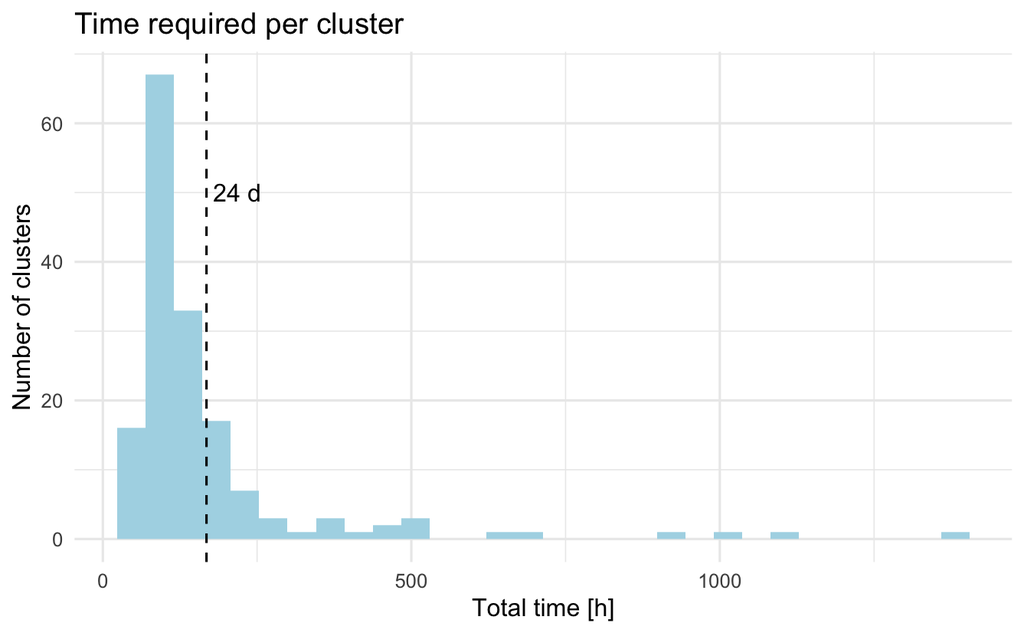

```r
field_worker_capacity <- (8-1)*24

df.workload %<>%
  mutate( total_time = cluster_visit_time + cluster_travel_time )

ggplot( df.workload, aes(total_time)) +
  geom_histogram(fill="lightblue") +
  geom_vline( xintercept = field_worker_capacity, linetype="dashed") +
  annotate( "text", x=50+field_worker_capacity, y=50, label="24 d") +
  labs( title = "Time required per cluster",
        x = "Total time [h]",
        y = "Number of clusters") +
  theme_minimal()
```

## Total estimates

Total workload for site in [h]

```r
site_work_load <- sum(df.workload$total_time)
site_work_load
```

```
[1] 26943.6
```

Given field worker capacity, calculate number of field workers required.

```r
site_work_load / field_worker_capacity
```

```
[1] 160.3786
```

## Visualization

Criticality categories: - >95% of total workload = red - 80-95% of total workload = yellow - <80% of total workload = green

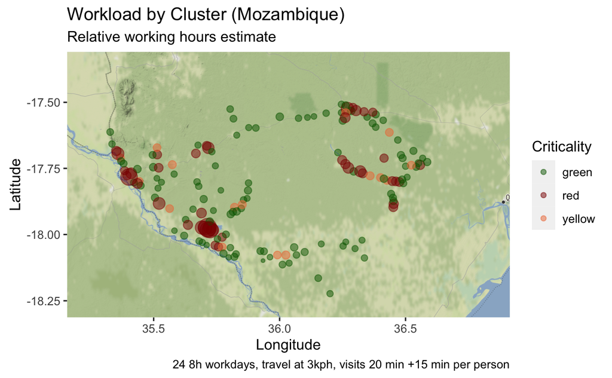

## Interactive table

```r
datatable(df.workload %>% select(-lng, -lat, -node_weight))
```

|  | cluster | cluster_visit_time | n | tour | cluster_travel_time | total_time | criticality |
| --- | --- | --- | --- | --- | --- | --- | --- |
| 1 | 1 | 83 | 48 | 6420.98983888046 | 26.1403299462935 | 109.140329946293 | green |
| 2 | 2 | 69 | 48 | 10089.1389603481 | 27.363046320116 | 96.363046320116 | green |
| 3 | 3 | 70.3333333333333 | 43 | 5827.07585246789 | 23.4423586174893 | 93.7756919508226 | green |
| 4 | 4 | 86.0833333333333 | 52 | 9489.63530947475 | 29.1632117698249 | 115.246545103158 | green |
| 5 | 5 | 98.5 | 63 | 4129.87118728539 | 32.8766237290951 | 131.376623729095 | green |
| 6 | 6 | 157.916666666667 | 104 | 4203.74491369935 | 53.4012483045665 | 211.317914971233 | red |
| 7 | 7 | 148.25 | 84 | 4721.48281619785 | 43.5738276053993 | 191.823827605399 | red |
| 8 | 8 | 74.6666666666667 | 50 | 5077.97964726591 | 26.692659882422 | 101.359326549089 | green |
| 9 | 9 | 75.3333333333333 | 49 | 5106.23662236755 | 26.2020788741225 | 101.535412207456 | green |
| 10 | 10 | 127.333333333333 | 79 | 6825.46006283297 | 41.7751533542777 | 169.108486687611 | red |

[output cut: 149 more lines]